# 《R + Amos + SPSS》

王超

26-07-2026

# 1 多元统计基础(M.Statistics Fundamentals)

## 1.1 基本概念

- **总体(Population)**:Every possible individual element that we are interested in measuring.
- **样本(Sample)**:A portion of the population.
- **参数(Parameter)**:A parameter is a number that describes some characteristic of a population.
- **统计量(Statistic)**:A statistic is a number that describes some characteristic of a sample.

## 1.2 抽样方法和误差

### 1.2.1 抽样方法(常用)

- 【参考文献】
  - 杨卫婷.民间体育游戏对大班幼儿社会情感能力的影响研究[D].上海师范大学,2025.DOI:10.27312/d.cnki.gshsu.2025.001645.(P20)
  - 赵雨婷.短距离游泳运动员功能性准备活动的设计与应用[D].北京体育大学,2020.DOI:10.26961/d.cnki.gbjtu.2020.000491.(P23)
  - 王吉峰.基于IPA分析法的武汉市全民健身公共服务满意度研究[D].武汉体育学院,2025.DOI:10.27384/d.cnki.gwhtc.2025.000005.(P30)
  - 杨海峰,寿碧琪,邵一宇.杭州市富阳区老年高血压患者脑卒中高危人群现状及危险因素[J].江苏预防医学,2024,35(04):435-438.DOI:10.13668/j.issn.1006-9070.2024.04.008.
  - 赵雨.某社区老年人社会健康现状及其相关因素研究[D].吉林大学,2025.DOI:10.27162/d.cnki.gjlin.2025.001491.(P11)
- 概率抽样方法(Probability Sampling Methods)
  - 简单随机抽样(Simple random sample):Every member of a population has an equal chance of being selected to be in the sample.
  - 分层抽样(Stratified random sample):Split a population into groups. Randomly select some members from each group to be in the sample.
  - 整群抽样(Cluster random sample):Split a population into clusters. Randomly select some of the clusters and include all members from those clusters in the sample.
  - 系统抽样(Systematic random sample):Put every member of a population into some order. Choosing a random starting point and select every nth member to be in the sample.
- 非概率抽样(Non-Probability Sampling Methods)
  - 偶遇
  - 判断
  - 推荐
  - 便利

### 1.2.2 误差

- 误差 = 测量值 - 真实值
- 常见误差： **随机误差**、过失误差、系统误差、**抽样误差**
- 证据强度：不同测量方式所提供证据的强度（或效度）存在差异，源于其测量误差的来源与可控性（识别、量化、预防或校正的可行性与难易程度）差异。
  - 主观量表（测量心理潜变量）：误差来源复杂（系统误差与随机误差并存），直接可控性低，需依赖严谨的量表设计与复杂的统计方法来验证与校正。
  - 行为测量、生理测量等（测量可直接观测的显变量）：误差来源结构清晰，直接可控性高，通常可通过标准化程序直接预防或量化。
- 如何提升量表的证据强度/效度：
  - 数据清洗与项目分析
  - 信、效度检验（内部一致性信度，重测信度；结构效度，聚敛效度和区分效度)

  > 在现代测量理论中，效度被视为一系列证据的整合，而非单一统计指标（Messick, 1989；AERA et al., 2014）。

  > Validity evidence based on internal structure, including **factor structure**, **convergent validity**, and **discriminant validity**.
  - 共同方法偏差的程序控制与统计诊断
- 量表误差 ➢ 信度检验 ➢➢ 效度检验 ➢➢➢ 推论可信度
- 误差与测量可靠性的统计学理解

## 1.3 变量类型/测量尺度

### 1.3.1 离散型数据(Discrete Data)

- 类变量(Nominal Scale)
  - Gender: Male, female
  - Marital Status: Single, Married, Divorced, Widowed
  - Blood type: O-, O+, A-, A+, B-, B+, AB-, AB+
- 序变量(Ordinal Scale)
  - Education Level: Primary, Junior Secondary, Senior Secondary, Bachelor’s, Master’s, PHD
  - Final Ranking: Champion(Gold Medalist), Runner-up(Silver Medalist), Third place(Bronze Medalist)
  - **Satisfaction: Very satisfied, satisfied, neutral, unsatisfied, very unsatisfied**
  - ( Note:As items within a scale, satisfaction ratings are frequently treated as continuous data.)

### 1.3.2 连续型数据(Continuous Data)

- Temperature
- Heigth,Weigth,Length

### 1.3.3 Summary

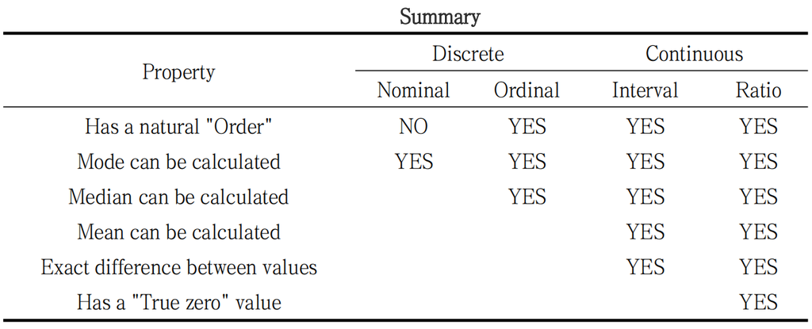

### 1.3.4 案例数据集

- SPSS基础-案例数据集链接

### 1.3.5 操作视频

- SPSS基础-操作视频链接

## 1.4 趋势量

- 【参考文献】
  - 赵雨婷.短距离游泳运动员功能性准备活动的设计与应用[D].北京体育大学,2020.DOI:10.26961/d.cnki.gbjtu.2020.000491.(P23-M+/-SD)
  - 石春芳.4周中高等强度运动对7-9岁儿童认知能力的影响[D].上海体育学院,2022.DOI:10.27315/d.cnki.gstyx.2022.000196.(P27-28,31-IQR)
  - 刘畅.民族传统体育专业散打专项本科生基本技能评价指标体系的构建[D].北京体育大学,2020.DOI:10.26961/d.cnki.gbjtu.2020.000129.(P27-CV)

### 1.4.1 集中趋势量

[Measures of Central Tendency](https://www.statology.org/measures-central-tendency/)

- 平均数(Average, M)
  - $\overline{x} = \frac{ \Sigma x_{i} }{n}$
- 中位数(Median, Mdn)
  - $M_{e} =\begin{cases}\frac{x_{n} + x_{n+1} }{2} & x \sim odd\\ x_{ \frac{n+1}{2} } & x \sim even\end{cases}$
- 众数(Mode)

### 1.4.2 离散趋势量

[Measures of Dispersion](https://www.statology.org/measures-dispersion/)

- 全距(Range)
  - $R = x_{max} - x_{min}$
- 四分位距(Interquartile Range, IQR)
  - Q1(The 25th percentile)、Q2(The 50th percentile; Mdn)、Q3(The 75th percentile)
  - IQR = Q3 - Q1
  - Mild-Outliers(°): (< Q1 - 1.5IQR) or (> Q3 + 1.5IQR)
  - Extreme-Outliers(*): (< Q1 - 3IQR) or (> Q3 + 3IQR)
  - 注：如果存在特异值，最大值（最小值）为去除特异值后剩余数据的最大值（最小值），箱线图辅助说明。
  - Outlier
- 方差/标准差(Variance/Standard Deviation, SD)
  - $s = \sqrt{ \frac{ \Sigma ( x_{i} - \overline{x} )^{2} }{n-1} }$
- 变异系数(CV)
  - $CV = \frac{s}{ \overline{x} } \times 100\%$

### 1.4.3 案例数据集

- 样本描述-案例数据集链接

### 1.4.4 操作视频

- 样本描述-操作视频链接

## 1.5 概率分布

### 1.5.1 正态分布

### 1.5.2 正态分布-密度曲线

[R ShinyApps - Norminal-Distribution](http://110.40.140.177:3838/Normal-Distribution/Normal-Distribution.Rmd)

[figure not shown]

### 1.5.3 正态性检验

- 【参考文献】
  - 石春芳.4周中高等强度运动对7-9岁儿童认知能力的影响[D].上海体育学院,2022.DOI:10.27315/d.cnki.gstyx.2022.000196.(P27,28-SW-Test)
- Normality Test
  - **Null hypothesis**: Normal Distribution; **Alternative hypothesis**: Non-normal Distribution
  - **Large Sample**: **K**olmogorov**-S**mirnov normality test
  - **Small Sample**: **S**hapiro**-W**ilk normality test

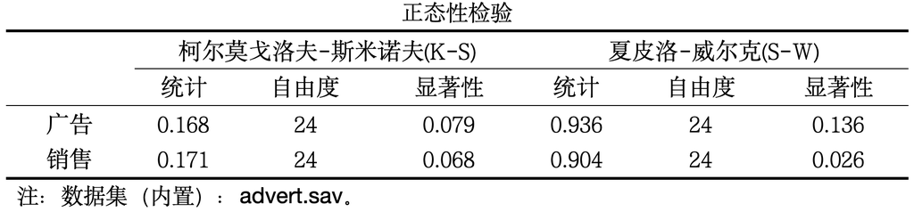

### 1.5.4 案例数据集

- 正态性检验-案例数据集链接

### 1.5.5 操作视频

- 正态性检验-操作视频链接

## 1.6 置信区间

### 1.6.1 Confidence Interval

- [Confidence Interval](https://www.statology.org/confidence-intervals/)
- 【参考文献】
  - 刘卓筱.八周篮球运动对七年级学生执行功能和情绪稳定性的影响研究[D].上海体育大学,2024.DOI:10.27315/d.cnki.gstyx.2024.000463.(P26-CI)
- A Confidence Interval(**CI**) is a range of values**[ LLCI, ULCI ]** that is likely to contain a population parameter with **a certain level of confidence**.

(Note:LLCI: Lower Limit of the Confidence Interval; ULCI: Upper Limit of the Confidence Interval.)

- Confidence Interval[ **LLCI , ULCI** ] = (point estimate) +/- (critical value)*(standard error)

### 1.6.2 案例数据集

- 置信区间-案例数据集链接

### 1.6.3 操作视频

- 置信区间-操作视频链接

## 1.7 SPSS-Sample Files

- 【文件(F)】——[欢迎对话框(W)]——“样本文件”
- [Sample DataSet 帮助文档](https://www.ibm.com/docs/zh/spss-statistics/26.0.0?topic=system-sample-files)

## 1.8 SPSS 变量属性

- 【案例:Accidents.sav
- [变量命名规则](https://www.ibm.com/docs/zh/spss-statistics/26.0.0?topic=view-variable-names)

## 1.9 实践作业

- 问卷样本描述-案例数据集链接
- 问卷样本描述-推荐汇报格式